# DATA 606 Data Project Proposal

KoohPy <- Koohyar Pooladvand

2024-04-20

### Data Preparation

In this project, I have chosen to work on breast cancer. There are various resources available regarding this particular topic, with the SEER being the most reliable one.

The Surveillance, Epidemiology, and End Results (SEER) Program of the National Cancer Institute (NCI) collects and publishes cancer data through a coordinated system of strategically placed cancer registries, which cover nearly 30% of the US population.

Currently, there are 18 SEER registries in the USA. This information can be found on the following website: https://seer.cancer.gov/data/access.html.

I have also used the following repository to assist me with this project: https://github.com/kohyarp/SEER_solid_tumor. The Database contains tons of data, the goal of my investigation will be focused only on BREAST cancer for 2011-2015 and 2019-2020. SEER has a software *STAT that I have used to import the data to a test that will be stored and used on my local computer. Additionally there is a GITHUB repository that I have used to some extent in this project. The repository is focused on all type of cancer, but my study is focused on BREAST, and I aim different question to answer. https://github.com/zgalochkina/SEER_solid_tumor

### Research question

The primary question I aim to address is the survival rate of breast cancers and the influence of factors such as age, type, sex, and other parameters on this rate. Notably, a five-year threshold is commonly used to determine survival rates. Although my understanding of the rationale behind this five-year benchmark is limited, recognizing its significance has led me to divide the data into two separate datasets.

This analysis is not scientific but rather a straightforward statistical exercise with no purpose beyond this course. However, I find the subject intriguing to investigate. I am uncertain if I will discover any significant relationships or correlations, and if found, whether they will be relevant, as I am not an expert in the field of breast cancer. My choice of topic is personal, as I have witnessed immediate family members diagnosed with this cancer, and I wish to gain a deeper understanding.

The database for 2011-2015 contains approximately 303,000 rows with 36 selected columns. I have chosen to focus solely on the 2019-2020 data, which comprises about 131,000 rows for prediction purposes. The question at hand is complex, and while I do not anticipate a definitive answer, I hope to uncover some patterns and test hypotheses, as well as engage in general data work, from tidying to cleaning.

Furthermore, I plan to explore regression analysis to determine if I can identify any linear or non-linear relationships among the critical parameters.

My knowledge of the subject is not extensive, but I am eager to learn as I progress.

Some of the general parameters to consider are as follows: * Years of diagnoses; * Age groups at diagnosis; * Cancer type (BREAST);

Some other parameters are also available to be edited, but they are secondary.

```r
# Replace "file.txt" with the path to your text file
directory <- "C:/Users/kohya/OneDrive/CUNY/DATA 606/DATA 606 Spring/Project"
file_2020 <- "BREAST_2019-2020-updated.csv"
file_serv <- "BREAST_2011-2015.csv"
# Complete the file path
full_path_serv <- file.path(directory, file_serv)
full_path_eval<- file.path(directory, file_2020)


BREAST_DF_surv <- read.csv(full_path_serv, header = TRUE,
                      na.strings = "NA", check.names = FALSE)
BREAST_DF_eval <- read.csv(full_path_eval, header = TRUE,
                      na.strings = "NA", check.names = FALSE)

labels_of_interest <- c("Primary Site - labeled")

# View the first few rows of the data frame
kable(head(BREAST_DF_surv, 10))
```

| Sex | Year of diagnosis | Race recode (W, B, AI, API) | Race and origin recode (NHW, NHB, NHAIAN, NHAPI, Hispanic) | Site recode ICD-O-3/WHO 2008 | Site recode ICD-O-3 2023 Revision | Primary Site - labeled | Grade Recode (thru 2017) | Grade Clinical (2018+) | Grade Pathological (2018+) | Diagnostic Confirmation | Laterality | Chemotherapy recode (yes, no/unk) | Radiation recode | Months from diagnosis to treatment | Reason no cancer-directed surgery | Scope of reg lymph nd surg (1998-2002) | Survival months flag | Survival months | COD to site recode | First malignant primary indicator | Sequence number | Total number of in situ/malignant tumors for patient | Total number of benign/borderline tumors for patient | Patient ID | Marital status at diagnosis | Median household income inflation adj to 2021 | Rural-Urban Continuum Code | Age recode (<60,60-69,70+) | Race and origin (recommended by SEER) | … |
| --- | --- | --- | --- | --- | --- | --- | --- | --- | --- | --- | --- | --- | --- | --- | --- | --- | --- | --- | --- | --- | --- | --- | --- | --- | --- | --- | --- | --- | --- | --- |
| Female | 2015 | White | Non-Hispanic White | Breast | Breast | C50.4-Upper-outer quadrant of breast | Moderately differentiated; Grade II | Blank(s) | Blank(s) | Positive histology | Right - origin of primary | Yes | Beam radiation | 002 | Surgery performed | Blank(s) | Complete dates are available and there are more than 0 days of survival | 0060 | Alive | No | 2nd of 2 or more primaries | 02 | 0 | 309 | Married (including common law) | $75,000+ | Counties in metropolitan areas ge 1 million pop | 50-54 years | All races/ethnicities | … |
| Female | 2013 | White | Non-Hispanic White | Breast | Breast | C50.9-Breast, NOS | Unknown | Blank(s) | Blank(s) | Positive histology | Right - origin of primary | No/Unknown | None/Unknown | Blank(s) | Not recommended | Blank(s) | Complete dates are available and there are more than 0 days of survival | 0028 | Breast | No | 3rd of 3 or more primaries | 03 | 0 | 346 | Divorced | $75,000+ | Counties in metropolitan areas ge 1 million pop | 40-44 years | All races/ethnicities | … |
| Female | 2012 | White | Non-Hispanic White | Breast | Breast | C50.2-Upper-inner quadrant of breast | Moderately differentiated; Grade II | Blank(s) | Blank(s) | Positive histology | Right - origin of primary | No/Unknown | None/Unknown | 004 | Surgery performed | Blank(s) | Complete dates are available and there are more than 0 days of survival | 0099 | Alive | No | 2nd of 2 or more primaries | 03 | 0 | 374 | Widowed | $75,000+ | Counties in metropolitan areas ge 1 million pop | 80-84 years | All races/ethnicities | … |
| Female | 2014 | White | Non-Hispanic White | Breast | Breast | C50.8-Overlapping lesion of breast | Moderately differentiated; Grade II | Blank(s) | Blank(s) | Positive histology | Right - origin of primary | No/Unknown | None/Unknown | 001 | Surgery performed | Blank(s) | Complete dates are available and there are more than 0 days of survival | 0081 | Alive | No | 2nd of 2 or more primaries | 02 | 0 | 391 | Married (including common law) | $75,000+ | Counties in metropolitan areas ge 1 million pop | 55-59 years | All races/ethnicities | … |
| Female | 2011 | Black | Non-Hispanic Black | Breast | Breast | C50.9-Breast, NOS | Unknown | Blank(s) | Blank(s) | Direct visualization without microscopic confirmation | Left - origin of primary | No/Unknown | None/Unknown | Blank(s) | Not recommended | Blank(s) | Complete dates are available and there are more than 0 days of survival | 0010 | Breast | No | 2nd of 2 or more primaries | 02 | 0 | 547 | Widowed | $75,000+ | Counties in metropolitan areas ge 1 million pop | 85+ years | All races/ethnicities | … |
| Female | 2013 | White | Hispanic (All Races) | Breast | Breast | C50.9-Breast, NOS | Moderately differentiated; Grade II | Blank(s) | Blank(s) | Positive histology | Right - origin of primary | No/Unknown | Beam radiation | 001 | Surgery performed | Blank(s) | Complete dates are available and there are more than 0 days of survival | 0086 | Alive | No | 2nd of 2 or more primaries | 02 | 0 | 567 | Married (including common law) | $75,000+ | Counties in metropolitan areas ge 1 million pop | 70-74 years | All races/ethnicities | … |
| Female | 2015 | White | Non-Hispanic White | Breast | Breast | C50.8-Overlapping lesion of breast | Unknown | Blank(s) | Blank(s) | Positive histology | Left - origin of primary | Yes | None/Unknown | 001 | Not recommended | Blank(s) | Complete dates are available and there are more than 0 days of survival | 0017 | Breast | No | 2nd of 2 or more primaries | 02 | 0 | 760 | Widowed | $75,000+ | Counties in metropolitan areas ge 1 million pop | 75-79 years | All races/ethnicities | … |
| Female | 2015 | White | Hispanic (All Races) | Breast | Breast | C50.4-Upper-outer quadrant of breast | Poorly differentiated; Grade III | Blank(s) | Blank(s) | Positive histology | Right - origin of primary | No/Unknown | None/Unknown | 001 | Surgery performed | Blank(s) | Complete dates are available and there are more than 0 days of survival | 0007 | Other Cause of Death | No | 2nd of 2 or more primaries | 02 | 0 | 941 | Widowed | $75,000+ | Counties in metropolitan areas ge 1 million pop | 85+ years | All races/ethnicities | … |
| Female | 2015 | White | Non-Hispanic White | Breast | Breast | C50.9-Breast, NOS | Poorly differentiated; Grade III | Blank(s) | Blank(s) | Positive histology | Right - origin of primary | No/Unknown | Beam radiation | 001 | Surgery performed | Blank(s) | Complete dates are available and there are more than 0 days of survival | 0043 | Cerebrovascular Diseases | No | 2nd of 2 or more primaries | 02 | 0 | 2056 | Widowed | $75,000+ | Counties in metropolitan areas ge 1 million pop | 80-84 years | All races/ethnicities | … |
| Female | 2015 | Black | Non-Hispanic Black | Breast | Breast | C50.8-Overlapping lesion of breast | Poorly differentiated; Grade III | Blank(s) | Blank(s) | Positive histology | Right - origin of primary | No/Unknown | None/Unknown | 001 | Surgery performed | Blank(s) | Complete dates are available and there are more than 0 days of survival | 0070 | Alive | No | 3rd of 3 or more primaries | 04 | 0 | 2605 | Divorced | $75,000+ | Counties in metropolitan areas ge 1 million pop | 60-64 years | All races/ethnicities | … |

```r
kable(head(BREAST_DF_eval, 10))
```

| Sex | Year of diagnosis | Race recode (W, B, AI, API) | Race and origin recode (NHW, NHB, NHAIAN, NHAPI, Hispanic) | Site recode ICD-O-3/WHO 2008 | Site recode ICD-O-3 2023 Revision | Primary Site - labeled | Grade Recode (thru 2017) | Grade Clinical (2018+) | Grade Pathological (2018+) | Diagnostic Confirmation | Laterality | Chemotherapy recode (yes, no/unk) | Radiation recode | Months from diagnosis to treatment | Reason no cancer-directed surgery | Scope of reg lymph nd surg (1998-2002) | Survival months flag | Survival months | COD to site recode | First malignant primary indicator | Sequence number | Total number of in situ/malignant tumors for patient | Total number of benign/borderline tumors for patient | Patient ID | Marital status at diagnosis | Median household income inflation adj to 2021 | Rural-Urban Continuum Code | Age recode (<60,60-69,70+) | Race and origin (recommended by SEER) | … |
| --- | --- | --- | --- | --- | --- | --- | --- | --- | --- | --- | --- | --- | --- | --- | --- | --- | --- | --- | --- | --- | --- | --- | --- | --- | --- | --- | --- | --- | --- | --- |
| Female | 2019 | Asian or Pacific Islander | Non-Hispanic Asian or Pacific Islander | Breast | Breast | C50.8-Overlapping lesion of breast | Unknown | 1 | 1 | Positive histology | Right - origin of primary | No/Unknown | None/Unknown | 002 | Surgery performed | Blank(s) | Complete dates are available and there are more than 0 days of survival | 0019 | Alive | No | 2nd of 2 or more primaries | 02 | 0 | 2750 | Divorced | $75,000+ | Counties in metropolitan areas ge 1 million pop | 65-69 years | All races/ethnicities | … |
| Female | 2020 | Asian or Pacific Islander | Non-Hispanic Asian or Pacific Islander | Breast | Breast | C50.8-Overlapping lesion of breast | Unknown | 2 | 9 | Positive histology | Right - origin of primary | No/Unknown | None/Unknown | 000 | Recommended, unknown if performed | Blank(s) | Complete dates are available and there are more than 0 days of survival | 0000 | Alive | No | 2nd of 2 or more primaries | 02 | 0 | 2870 | Married (including common law) | $75,000+ | Counties in metropolitan areas ge 1 million pop | 75-79 years | All races/ethnicities | … |
| Female | 2020 | White | Non-Hispanic White | Breast | Breast | C50.4-Upper-outer quadrant of breast | Unknown | 1 | 2 | Positive histology | Right - origin of primary | No/Unknown | None/Unknown | 000 | Surgery performed | Blank(s) | Complete dates are available and there are more than 0 days of survival | 0007 | Alive | No | 2nd of 2 or more primaries | 02 | 0 | 3067 | Divorced | $75,000+ | Counties in metropolitan areas ge 1 million pop | 85+ years | All races/ethnicities | … |
| Female | 2020 | White | Non-Hispanic White | Breast | Breast | C50.5-Lower-outer quadrant of breast | Unknown | 2 | 9 | Positive histology | Right - origin of primary | Yes | None/Unknown | 001 | Surgery performed | Blank(s) | Complete dates are available and there are more than 0 days of survival | 0010 | Alive | No | 2nd of 2 or more primaries | 02 | 0 | 3365 | Widowed | $75,000+ | Counties in metropolitan areas ge 1 million pop | 85+ years | All races/ethnicities | … |
| Female | 2019 | White | Non-Hispanic White | Breast | Breast | C50.8-Overlapping lesion of breast | Unknown | 2 | 2 | Positive histology | Right - origin of primary | No/Unknown | Radioactive implants (includes brachytherapy) (1988+) | 000 | Surgery performed | Blank(s) | Complete dates are available and there are more than 0 days of survival | 0016 | Alive | No | 3rd of 3 or more primaries | 03 | 0 | 3679 | Divorced | $75,000+ | Counties in metropolitan areas ge 1 million pop | 75-79 years | All races/ethnicities | … |
| Female | 2019 | Asian or Pacific Islander | Non-Hispanic Asian or Pacific Islander | Breast | Breast | C50.9-Breast, NOS | Unknown | 2 | 2 | Positive histology | Right - origin of primary | No/Unknown | None/Unknown | 004 | Surgery performed | Blank(s) | Complete dates are available and there are more than 0 days of survival | 0014 | Alive | No | 3rd of 3 or more primaries | 04 | 0 | 3771 | Married (including common law) | $75,000+ | Counties in metropolitan areas ge 1 million pop | 55-59 years | All races/ethnicities | … |
| Female | 2019 | Asian or Pacific Islander | Non-Hispanic Asian or Pacific Islander | Breast | Breast | C50.4-Upper-outer quadrant of breast | Unknown | 1 | 1 | Positive histology | Left - origin of primary | No/Unknown | None/Unknown | 004 | Surgery performed | Blank(s) | Complete dates are available and there are more than 0 days of survival | 0014 | Alive | No | 4th of 4 or more primaries | 04 | 0 | 3771 | Married (including common law) | $75,000+ | Counties in metropolitan areas ge 1 million pop | 55-59 years | All races/ethnicities | … |
| Female | 2020 | White | Non-Hispanic White | Breast | Breast | C50.8-Overlapping lesion of breast | Unknown | 2 | 9 | Positive histology | Right - origin of primary | No/Unknown | None/Unknown | 001 | Surgery performed | Blank(s) | Complete dates are available and there are more than 0 days of survival | 0003 | Alive | No | 2nd of 2 or more primaries | 02 | 0 | 6501 | Married (including common law) | $75,000+ | Counties in metropolitan areas ge 1 million pop | 80-84 years | All races/ethnicities | … |
| Female | 2020 | White | Non-Hispanic White | Breast | Breast | C50.3-Lower-inner quadrant of breast | Unknown | 1 | 1 | Positive histology | Left - origin of primary | No/Unknown | None/Unknown | 002 | Surgery performed | Blank(s) | Complete dates are available and there are more than 0 days of survival | 0007 | Alive | No | 3rd of 3 or more primaries | 03 | 0 | 7723 | Married (including common law) | $75,000+ | Counties in metropolitan areas ge 1 million pop | 70-74 years | All races/ethnicities | … |
| Female | 2019 | White | Non-Hispanic White | Breast | Breast | C50.4-Upper-outer quadrant of breast | Unknown | 2 | 9 | Positive histology | Right - origin of primary | Yes | None/Unknown | 002 | Surgery performed | Blank(s) | Complete dates are available and there are more than 0 days of survival | 0021 | Alive | No | 2nd of 2 or more primaries | 02 | 0 | 8406 | Unmarried or Domestic Partner | $75,000+ | Counties in metropolitan areas ge 1 million pop | 55-59 years | All races/ethnicities | … |

### Cases

**What are the cases, and how many are there?** There are 131,395 cases in the BREAST cancer list of 2019-2020. And There are 303557 in 2011-2015 dataset.

https://medium.com/@navamisunil174/exploratory-data-analysis-of-breast-cancer-survival-prediction-dataset-c423e4137e38

### Data collection

- The SEER program collects cancer incidence data through a network of population-based cancer registries. These registries gather information on patient demographics, primary tumor site, tumor morphology, stage at diagnosis, and first course of treatment. They also follow up with patients for vital status.
- By law, these facilities are required to report new cancer cases to a central cancer registry, like a state cancer registry.
- [The SEER program releases new research data annually, based on submissions from the previous year, and makes it available for public use through a data request process](https://seer.cancer.gov/data-software/). This comprehensive approach ensures that the SEER database is a valuable resource for cancer research and surveillance.

https://training.seer.cancer.gov/registration/data/collection.html

### Type of study

This will be an observational study, information is gathered for different patients and I will be evaluating the available data to present and evaluate.

**What type of study is this (observational/experiment)?**

### Dependent Variable

Categorical features, such as ‘Median household income …’ ‘Marital Status,’ ‘Grade recode’ ‘laterality’ and ‘Radiatio recode’ and so on are represented as objects (characters).

*The event indicator refers to the death and the time registered is either the time-to-event (when the individual eventually dies) or the time-to-censorship (the event is not observed), measured in months.*

```r
# Find unique values in each column
# Apply function to find unique values for each column

unique_values <- data.frame(unique = apply(BREAST_DF_surv, 2, function(x) length(unique(x))),colnames = colnames(BREAST_DF_surv))

# Check for NULL values
any_null <- any(sapply(BREAST_DF_surv, is.null))

# Check for NA values
any_na <- any(sapply(BREAST_DF_surv, is.na))

# Check if there are any NULL or NA values
if (any_null || any_na) {
  print("The data frame contains NULL or NA values.")
} else {
  print("The data frame does not contain any NULL or NA values.")
}
```

```
## [1] "The data frame does not contain any NULL or NA values."
```

```r
has_na_character <- any(sapply(BREAST_DF_surv, function(x) any(x == "NA")))

if (has_na_character) {
  print("The data frame contains character values of 'NA'.")
} else {
  print("The data frame does not contain character values of 'NA'.")
}
```

```
## [1] "The data frame does not contain character values of 'NA'."
```

### Data tyding

Upon exploring the data, it seems data might have an empty column, in this data-based, the empty values are filled with “Blanks”. Thus, in this section, I first explore if there is any column which is entirely empty, then will remove it and if there are others which have some empty values filled with “blancked” I will repalced them with “NA” whoch is handled better in dplyr and tydiverse.

```r
# There are cells in the DF that contianes "Blank(s) which is literally NA, first I want to find if there is any column that all is values is Blank(s), if then remove them.

#look for columns with all "Blank(s)" values
Empty_column <- BREAST_DF_surv %>%
  dplyr::summarise(dplyr::across(everything(), ~all(. == "Blank(s)"))) %>%
  as.logical() %>%
  unlist()

# Get the names of columns with all cells containing "Blank(s)"
blank_column_names <- names( BREAST_DF_surv)[Empty_column]

# Print the column names with all cells containing "Blanks"
print(blank_column_names)
```

```
## [1] "Grade Clinical (2018+)"
## [2] "Grade Pathological (2018+)"
## [3] "Scope of reg lymph nd surg (1998-2002)"
## [4] "Tumor Size Summary (2016+)"
```

```r
#remove those empty column from thr DF
BREAST_DF_surv <- BREAST_DF_surv[, !names(BREAST_DF_surv) %in% blank_column_names]
BREAST_DF_eval <- BREAST_DF_eval[, !names(BREAST_DF_eval) %in% blank_column_names]

#Then let's see if there is any cell in the remaining that migth still have "Blank(s)", if so repalce it with NS which is betetr handle in R

#This code first replaces all occurrences of "Blank(s)" with an empty string "", and then uses na_if() to convert the empty strings to NA. Now, all cells that previously had "Blank(s)" are replaced with NA, making it easier to handle missing values in R.

BREAST_DF_surv <- BREAST_DF_surv %>%
  mutate_if(is.character, ~ifelse(. == "Blank(s)", "", .)) %>%  # For character columns
  mutate_if(is.numeric, ~ifelse(. == "", as.numeric(NA), .))  # For numeric columns

# Now, empty character cells are replaced with NA
BREAST_DF_surv <- BREAST_DF_surv %>%
  mutate_if(is.character, na_if, "")


#same to be done for eval dataset


BREAST_DF_eval <- BREAST_DF_eval %>%
  mutate_if(is.character, ~ifelse(. == "Blank(s)", "", .)) %>%  # For character columns
  mutate_if(is.numeric, ~ifelse(. == "", as.numeric(NA), .))  # For numeric columns

# Now, empty character cells are replaced with NA
BREAST_DF_eval <- BREAST_DF_eval %>%
  mutate_if(is.character, na_if, "")

#Change characters to numerics
BREAST_DF_surv$`Months from diagnosis to treatment` <- as.numeric(BREAST_DF_surv$`Months from diagnosis to treatment`)
BREAST_DF_surv$`Survival months` <- as.numeric(BREAST_DF_surv$`Survival months`)
BREAST_DF_surv$`Total number of in situ/malignant tumors for patient` <-
  as.numeric(BREAST_DF_surv$`Total number of in situ/malignant tumors for patient`)
BREAST_DF_surv$`Total number of benign/borderline tumors for patient` <-
  as.numeric(BREAST_DF_surv$`Total number of benign/borderline tumors for patient`)
#Change the character to numeric in Eval dataset too
BREAST_DF_eval$`Months from diagnosis to treatment` <- as.numeric(BREAST_DF_eval$`Months from diagnosis to treatment`)
BREAST_DF_eval$`Survival months` <- as.numeric(BREAST_DF_eval$`Survival months`)
BREAST_DF_eval$`Total number of in situ/malignant tumors for patient` <-
  as.numeric(BREAST_DF_eval$`Total number of in situ/malignant tumors for patient`)
BREAST_DF_eval$`Total number of benign/borderline tumors for patient` <-
  as.numeric(BREAST_DF_eval$`Total number of benign/borderline tumors for patient`)


# View the structure of the data frame
#str(BREAST_DF_surv)
skimr::skim(BREAST_DF_surv)
```

Data summary

| Name | BREAST_DF_surv |
| --- | --- |
| Number of rows | 303557 |
| Number of columns | 32 |
| _______________________ |  |
| Column type frequency: |  |
| character | 25 |
| numeric | 7 |
| ________________________ |  |
| Group variables | None |

**Variable type: character**

| skim_variable | n_missing | complete_rate | min | max | empty | n_unique | whitespace |
| --- | --- | --- | --- | --- | --- | --- | --- |
| Sex | 0 | 1 | 6 | 6 | 0 | 1 | 0 |
| Race recode (W, B, AI, API) | 0 | 1 | 5 | 29 | 0 | 5 | 0 |
| Race and origin recode (NHW, NHB, NHAIAN, NHAPI, Hispanic) | 0 | 1 | 18 | 42 | 0 | 6 | 0 |
| Site recode ICD-O-3/WHO 2008 | 0 | 1 | 6 | 6 | 0 | 1 | 0 |
| Site recode ICD-O-3 2023 Revision | 0 | 1 | 6 | 6 | 0 | 1 | 0 |
| Primary Site - labeled | 0 | 1 | 12 | 36 | 0 | 9 | 0 |
| Grade Recode (thru 2017) | 0 | 1 | 7 | 38 | 0 | 5 | 0 |
| Diagnostic Confirmation | 0 | 1 | 7 | 57 | 0 | 9 | 0 |
| Laterality | 0 | 1 | 24 | 53 | 0 | 5 | 0 |
| Chemotherapy recode (yes, no/unk) | 0 | 1 | 3 | 10 | 0 | 2 | 0 |
| Radiation recode | 0 | 1 | 12 | 53 | 0 | 8 | 0 |
| Reason no cancer-directed surgery | 0 | 1 | 15 | 76 | 0 | 8 | 0 |
| Survival months flag | 0 | 1 | 61 | 73 | 0 | 5 | 0 |
| COD to site recode | 0 | 1 | 5 | 55 | 0 | 87 | 0 |
| First malignant primary indicator | 0 | 1 | 2 | 3 | 0 | 2 | 0 |
| Sequence number | 0 | 1 | 16 | 60 | 0 | 13 | 0 |
| Marital status at diagnosis | 0 | 1 | 7 | 30 | 0 | 7 | 0 |
| Median household income inflation adj to 2021 | 0 | 1 | 8 | 38 | 0 | 11 | 0 |
| Rural-Urban Continuum Code | 0 | 1 | 38 | 60 | 0 | 7 | 0 |
| Age recode (<60,60-69,70+) | 0 | 1 | 9 | 11 | 0 | 18 | 0 |
| Race and origin (recommended by SEER) | 0 | 1 | 21 | 21 | 0 | 1 | 0 |
| Year of death recode | 0 | 1 | 4 | 21 | 0 | 11 | 0 |
| SEER other cause of death classification | 0 | 1 | 16 | 55 | 0 | 4 | 0 |
| RX Summ–Systemic/Sur Seq (2007+) | 0 | 1 | 16 | 55 | 0 | 8 | 0 |
| Origin recode NHIA (Hispanic, Non-Hisp) | 0 | 1 | 23 | 27 | 0 | 2 | 0 |

**Variable type: numeric**

| skim_variable | n_missing | complete_rate | mean | sd | p0 | p25 | p50 | p75 | p100 | hist |
| --- | --- | --- | --- | --- | --- | --- | --- | --- | --- | --- |
| Year of diagnosis | 0 | 1.00 | 2013.04 | 1.42 | 2011 | 2012 | 2013 | 2014 | 2015 | ▇▇▇▇▇ |
| Months from diagnosis to treatment | 15843 | 0.95 | 1.13 | 1.14 | 0 | 0 | 1 | 2 | 24 | ▇▁▁▁▁ |
| Survival months | 1290 | 1.00 | 74.22 | 29.88 | 0 | 62 | 78 | 97 | 119 | ▂▂▆▇▆ |
| Total number of in situ/malignant tumors for patient | 3 | 1.00 | 1.36 | 0.65 | 1 | 1 | 1 | 2 | 20 | ▇▁▁▁▁ |
| Total number of benign/borderline tumors for patient | 0 | 1.00 | 0.01 | 0.09 | 0 | 0 | 0 | 0 | 5 | ▇▁▁▁▁ |
| Patient ID | 0 | 1.00 | 32479919.61 | 17852417.08 | 309 | 16624928 | 35389654 | 49353652 | 63287749 | ▃▅▇▂▅ |
| Year of follow-up recode | 0 | 1.00 | 2018.90 | 2.14 | 2011 | 2019 | 2020 | 2020 | 2020 | ▁▁▁▁▇ |

```r
skimr::skim(BREAST_DF_eval)
```

Data summary

| Name | BREAST_DF_eval |
| --- | --- |
| Number of rows | 131395 |
| Number of columns | 32 |
| _______________________ |  |
| Column type frequency: |  |
| character | 25 |
| numeric | 7 |
| ________________________ |  |
| Group variables | None |

**Variable type: character**

| skim_variable | n_missing | complete_rate | min | max | empty | n_unique | whitespace |
| --- | --- | --- | --- | --- | --- | --- | --- |
| Sex | 0 | 1 | 6 | 6 | 0 | 1 | 0 |
| Race recode (W, B, AI, API) | 0 | 1 | 5 | 29 | 0 | 5 | 0 |
| Race and origin recode (NHW, NHB, NHAIAN, NHAPI, Hispanic) | 0 | 1 | 18 | 42 | 0 | 6 | 0 |
| Site recode ICD-O-3/WHO 2008 | 0 | 1 | 6 | 6 | 0 | 1 | 0 |
| Site recode ICD-O-3 2023 Revision | 0 | 1 | 6 | 6 | 0 | 1 | 0 |
| Primary Site - labeled | 0 | 1 | 12 | 36 | 0 | 9 | 0 |
| Grade Recode (thru 2017) | 0 | 1 | 7 | 7 | 0 | 1 | 0 |
| Diagnostic Confirmation | 0 | 1 | 7 | 57 | 0 | 9 | 0 |
| Laterality | 0 | 1 | 24 | 53 | 0 | 5 | 0 |
| Chemotherapy recode (yes, no/unk) | 0 | 1 | 3 | 10 | 0 | 2 | 0 |
| Radiation recode | 0 | 1 | 12 | 53 | 0 | 8 | 0 |
| Reason no cancer-directed surgery | 0 | 1 | 15 | 76 | 0 | 8 | 0 |
| Survival months flag | 0 | 1 | 61 | 73 | 0 | 5 | 0 |
| COD to site recode | 0 | 1 | 5 | 55 | 0 | 67 | 0 |
| First malignant primary indicator | 0 | 1 | 2 | 3 | 0 | 2 | 0 |
| Sequence number | 0 | 1 | 16 | 60 | 0 | 16 | 0 |
| Marital status at diagnosis | 0 | 1 | 7 | 30 | 0 | 7 | 0 |
| Median household income inflation adj to 2021 | 0 | 1 | 8 | 38 | 0 | 11 | 0 |
| Rural-Urban Continuum Code | 0 | 1 | 38 | 60 | 0 | 7 | 0 |
| Age recode (<60,60-69,70+) | 0 | 1 | 9 | 11 | 0 | 17 | 0 |
| Race and origin (recommended by SEER) | 0 | 1 | 21 | 21 | 0 | 1 | 0 |
| Year of death recode | 0 | 1 | 4 | 21 | 0 | 3 | 0 |
| SEER other cause of death classification | 0 | 1 | 16 | 55 | 0 | 4 | 0 |
| RX Summ–Systemic/Sur Seq (2007+) | 0 | 1 | 16 | 55 | 0 | 8 | 0 |
| Origin recode NHIA (Hispanic, Non-Hisp) | 0 | 1 | 23 | 27 | 0 | 2 | 0 |

**Variable type: numeric**

| skim_variable | n_missing | complete_rate | mean | sd | p0 | p25 | p50 | p75 | p100 | hist |
| --- | --- | --- | --- | --- | --- | --- | --- | --- | --- | --- |
| Year of diagnosis | 0 | 1.00 | 2019.48 | 0.50 | 2019 | 2019 | 2019 | 2020 | 2020 | ▇▁▁▁▇ |
| Months from diagnosis to treatment | 6807 | 0.95 | 1.26 | 1.18 | 0 | 1 | 1 | 2 | 24 | ▇▁▁▁▁ |
| Survival months | 537 | 1.00 | 11.07 | 7.05 | 0 | 5 | 11 | 17 | 23 | ▇▆▆▇▆ |
| Total number of in situ/malignant tumors for patient | 11 | 1.00 | 1.31 | 0.62 | 1 | 1 | 1 | 1 | 50 | ▇▁▁▁▁ |
| Total number of benign/borderline tumors for patient | 0 | 1.00 | 0.01 | 0.09 | 0 | 0 | 0 | 0 | 2 | ▇▁▁▁▁ |
| Patient ID | 0 | 1.00 | 33137047.92 | 18037981.73 | 2750 | 16896696 | 36734406 | 49994270 | 63289421 | ▃▅▇▂▅ |
| Year of follow-up recode | 0 | 1.00 | 2019.98 | 0.14 | 2019 | 2020 | 2020 | 2020 | 2020 | ▁▁▁▁▇ |

### Relevant summary statistics

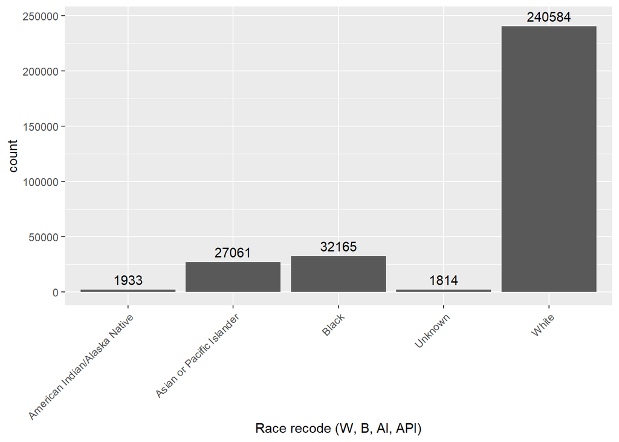

```r
#find column name to use later if needed
DF_col_names <- colnames(BREAST_DF_surv)

#Find unique values in `Race recode (W, B, AI, API)` column
uniques_races <- unique(BREAST_DF_surv$`Race recode (W, B, AI, API)`)

# use ggplot to plot the race information
BREAST_DF_surv |>
  ggplot(mapping = aes(x=`Race recode (W, B, AI, API)`)) +
  geom_bar(stat = "count") +
  theme(axis.text.x = element_text(angle = 45, hjust = 1)) +
  geom_text(aes(label = after_stat(count)), stat = "count", vjust = -0.5) +
  ylim(0, 246000)
```

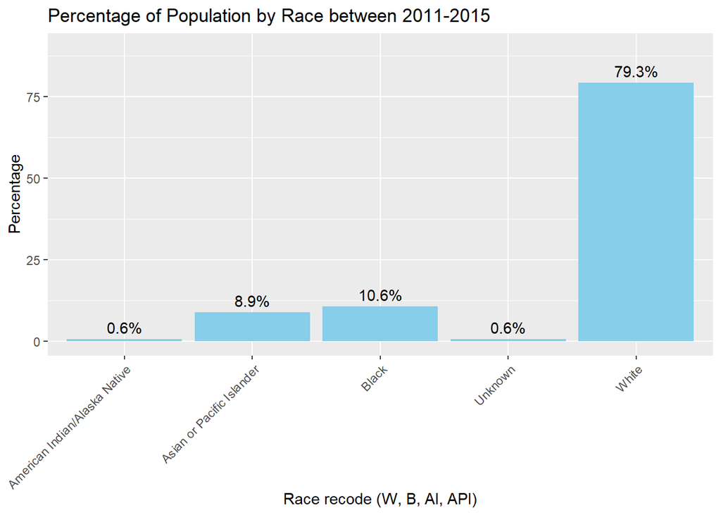

```r
#we want to coampre the percentage of the diferent race in the eval and survival data, thus i use sumamrise to create two new DF to only store the sumamry statistic specifically including the percentage of race based on the population
#find percentage of race for the survival
BREAST_DF_perc_surv <- BREAST_DF_surv %>%
  group_by(`Race recode (W, B, AI, API)`) %>%
  dplyr::summarise(count = dplyr::n()) %>%  # Calculate count per group
  ungroup() %>%  # Ungroup the data
  mutate(total_count = sum(count)) %>%  # Calculate total count
  mutate(percentage = count / total_count * 100)  # Calculate percentage using total count

# Plot the percentages
ggplot(BREAST_DF_perc_surv, aes(x = `Race recode (W, B, AI, API)`, y = percentage)) +
  geom_bar(stat = "identity", fill = "skyblue") +
  geom_text(aes(label = paste0(round(percentage, 1), "%")), vjust = -0.5, color = "black") +
  theme(axis.text.x = element_text(angle = 45, hjust = 1)) +
  labs(title = "Percentage of Population by Race between 2011-2015", x = "Race recode (W, B, AI, API)", y = "Percentage") + ylim (0,90)
```

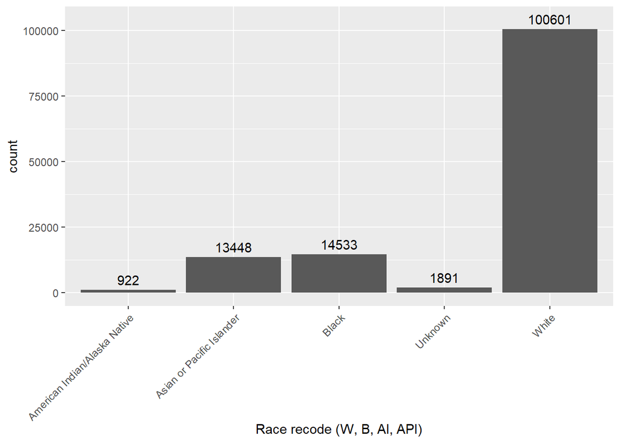

```r
BREAST_DF_eval |>
  ggplot(mapping = aes(x=`Race recode (W, B, AI, API)`)) +
  geom_bar(stat = "count") +
  theme(axis.text.x = element_text(angle = 45, hjust = 1)) +
  geom_text(aes(label = after_stat(count)), stat = "count", vjust = -0.5) +
  ylim(0, 104000)
```

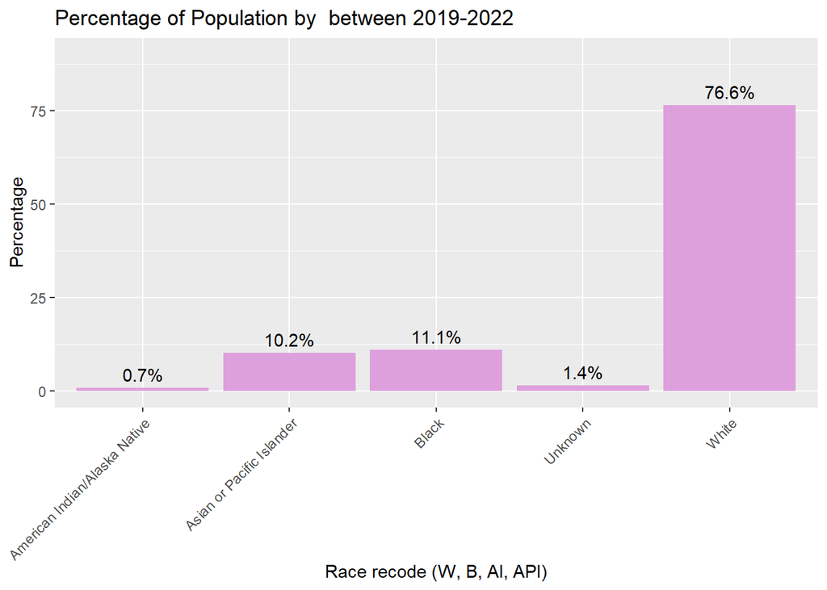

```r
BREAST_DF_perc_eval <- BREAST_DF_eval %>%
  group_by(`Race recode (W, B, AI, API)`) %>%
  dplyr::summarise(count = dplyr::n()) %>%  # Calculate count per group
  ungroup() %>%  # Ungroup the data
  mutate(total_count = sum(count)) %>%  # Calculate total count
  mutate(percentage = count / total_count * 100)  # Calculate percentage using total count

# Plot the percentages
ggplot(BREAST_DF_perc_eval, aes(x = `Race recode (W, B, AI, API)`, y = percentage)) +
  geom_bar(stat = "identity", fill = "plum") +
  geom_text(aes(label = paste0(round(percentage, 1), "%")), vjust = -0.5, color = "black") +
  theme(axis.text.x = element_text(angle = 45, hjust = 1)) +
  labs(title = "Percentage of Population by  between 2019-2022", x = "Race recode (W, B, AI, API)", y = "Percentage") + ylim (0,90)
```

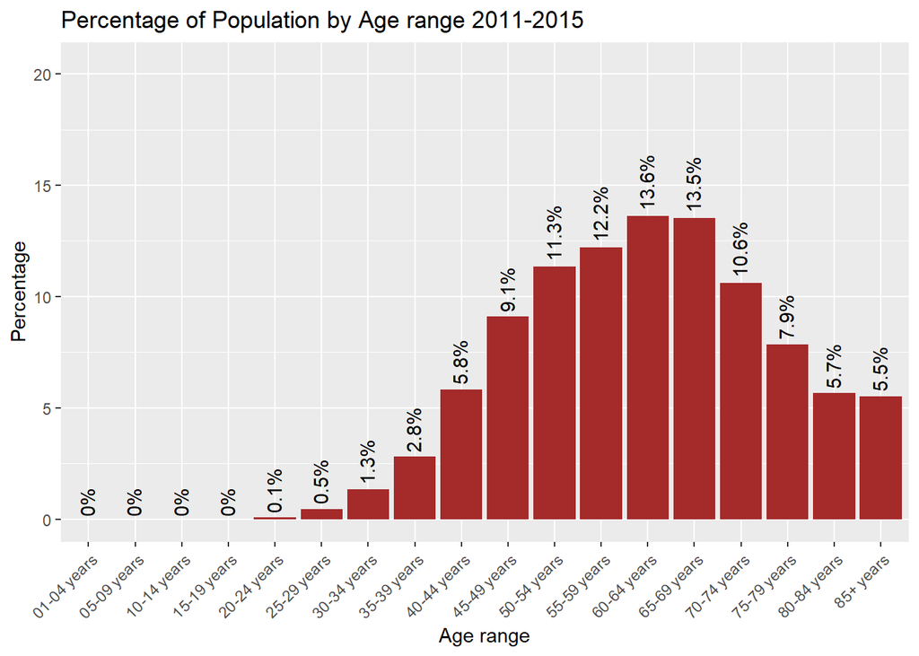

```r
# In this section I want to focus on the age and see if age matetrs, same sets of data is going to be plot for ages, starting with percentage for eval and surve
#find percentage of race for the survival
#find ubique values for column ratted to age
uniques_ages <- unique(BREAST_DF_surv[29])

BREAST_DF_age_perc_surv <- BREAST_DF_surv %>%
  dplyr::group_by(`Age recode (<60,60-69,70+)`) %>%
  dplyr::summarise(count = dplyr::n()) %>%  # Calculate count per group
  ungroup() %>%  # Ungroup the data
  mutate(total_count = sum(count)) %>%  # Calculate total count
  mutate(percentage = count / total_count * 100)  # Calculate percentage using total count

perc_max <- max(BREAST_DF_age_perc_surv$percentage)
# Plot the percentages
ggplot(BREAST_DF_age_perc_surv, aes(x = `Age recode (<60,60-69,70+)`, y = percentage)) +
  geom_bar(stat = "identity", fill = "brown") +
  geom_text(aes(label = paste0(round(percentage, 1), "%")), hjust = -0.1 , vjust = 0.4, color = "black", angle = 90) +  # Rotate the text vertically
  theme(axis.text.x = element_text(angle = 45, hjust = 1)) +labs(title = "Percentage of Population by Age range 2011-2015",
       x = "Age range",
       y = "Percentage") +
  ylim(0, round(1.5 * perc_max, 1))
```

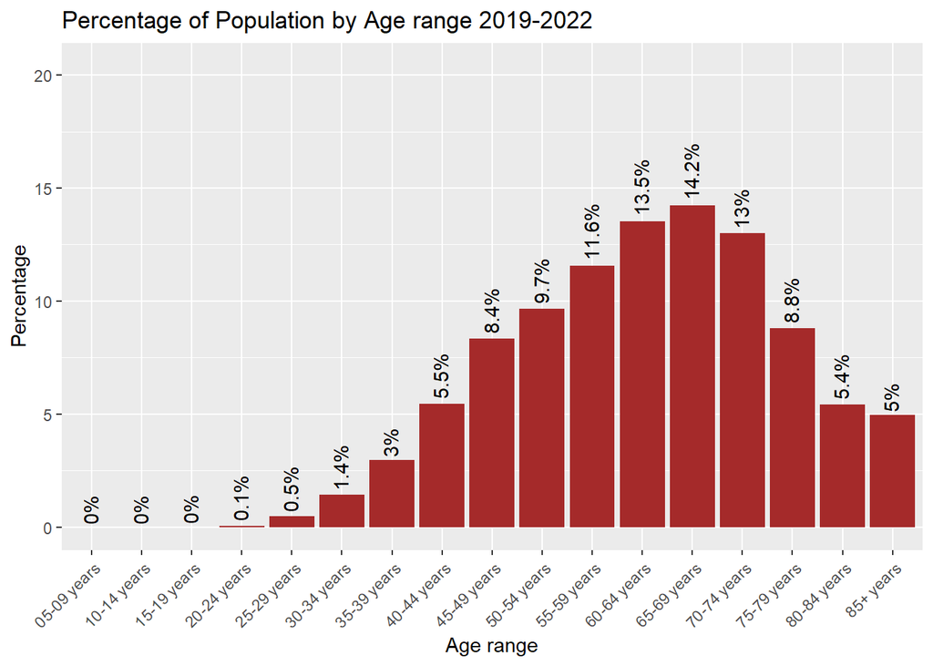

```r
# In this section we do the same analyses for Eval dta based on age
BREAST_DF_age_perc_eval <- BREAST_DF_eval %>%
  dplyr::group_by(`Age recode (<60,60-69,70+)`) %>%
  dplyr::summarise(count = dplyr::n()) %>%  # Calculate count per group
  ungroup() %>%  # Ungroup the data
  mutate(total_count = sum(count)) %>%  # Calculate total count
  mutate(percentage = count / total_count * 100)  # Calculate percentage using total count

# Plot the percentages
ggplot(BREAST_DF_age_perc_eval, aes(x = `Age recode (<60,60-69,70+)`, y = percentage)) +
  geom_bar(stat = "identity", fill = "brown") +
  geom_text(aes(label = paste0(round(percentage, 1), "%")), hjust = -0.1 , vjust = 0.4, color = "black", angle = 90) +  # Rotate the text vertically
  theme(axis.text.x = element_text(angle = 45, hjust = 1)) +labs(title = "Percentage of Population by Age range 2019-2022",
       x = "Age range",
       y = "Percentage") +
  ylim(0, round(1.5 * perc_max, 1))
```

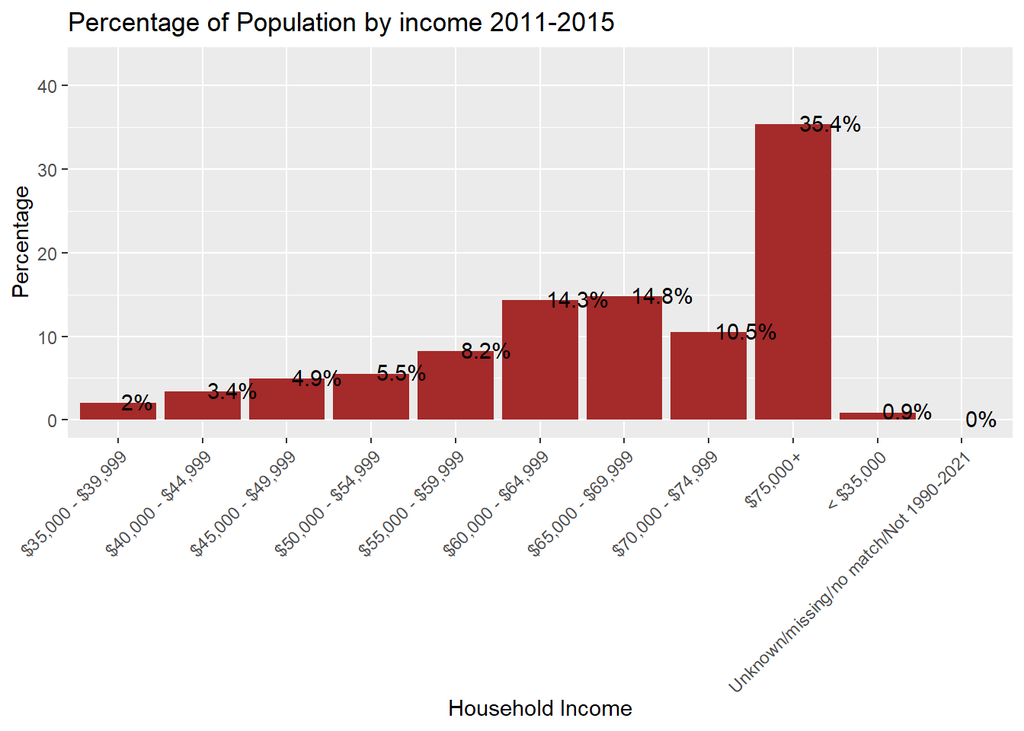

```r
# In this section, we do the analyses on household income}
#find ubique values for column ratted to age
uniques_householdes <- unique(BREAST_DF_surv[27])

BREAST_DF_income_perc_surv <- BREAST_DF_surv %>% dplyr::group_by(`Median household income inflation adj to 2021`) %>%
  dplyr::summarise(count = dplyr::n()) %>% # Calculate count per group
  ungroup() %>% # Ungroup the data
  mutate(total_count = sum(count)) %>% # Calculate total count
  mutate(percentage = count / total_count * 100) # Calculate percentage using total count

perc_max <- max(BREAST_DF_income_perc_surv$percentage) # Plot the percentages
ggplot(BREAST_DF_income_perc_surv, aes(x = `Median household income inflation adj to 2021`, y = percentage)) +
  geom_bar(stat = "identity", fill = "brown") +
  geom_text(aes(label = paste0(round(percentage, 1), "%")), hjust = -0.1 , vjust = 0.4, color = "black", angle = 0) +
  theme(axis.text.x = element_text(angle = 45, hjust = 1)) +
  labs(title = "Percentage of Population by income 2011-2015", x = "Household Income", y = "Percentage") +
  ylim(0, 1.2*perc_max)
```

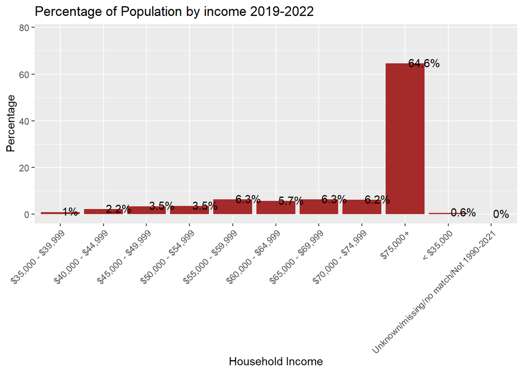

```r
#In this section we do the same analyses for Eval data based on age
BREAST_DF_income_perc_eval <- BREAST_DF_eval %>%
  dplyr::group_by(`Median household income inflation adj to 2021`) %>%
  dplyr::summarise(count = dplyr::n()) %>% # Calculate count per group
  ungroup() %>% # Ungroup the data
  mutate(total_count = sum(count)) %>% # Calculate total count
  mutate(percentage = count / total_count * 100) # Calculate percentage using total count


#Plot the percentages
perc_max <- max(BREAST_DF_income_perc_eval$percentage)
ggplot(BREAST_DF_income_perc_eval, aes(x = `Median household income inflation adj to 2021`, y = percentage)) +
  geom_bar(stat = "identity", fill = "brown") +
  geom_text(aes(label = paste0(round(percentage, 1), "%")), hjust = -0.1 , vjust = 0.4, color = "black", angle = 0) +
  theme(axis.text.x = element_text(angle = 45, hjust = 1)) +
  labs(title = "Percentage of Population by income 2019-2022", x = "Household Income", y = "Percentage") +
  ylim(0, 1.2*perc_max)
```

```r
# In this section I want to focus on the cause of dead, COD, and investigate whether those who have had cancer are alive, anf if no what was the cause of dead.
#find percentage of deceased due to breast cancer
#find unique values for column ratted to age

uniques_CODs <- unique(BREAST_DF_surv[20])
DF_col_names[20]
```

```
## [1] "Total number of in situ/malignant tumors for patient"
```

```r
# check if the column `COD to site recode` has value of Alive or Breast meaning they are still alive or have died because of breast cancer, and other passed a way but not because of Breast cancer.

BREAST_DF_surv <- BREAST_DF_surv %>%
  mutate(COD = ifelse(`COD to site recode` %in% c("Alive","Breast"), `COD to site recode`, "Other"))


BREAST_DF_COD_perc_surv <- BREAST_DF_surv %>%
  dplyr::group_by(COD) %>%
  dplyr::summarise(count = dplyr::n()) %>%  # Calculate count per group
  ungroup() %>%  # Ungroup the data
  mutate(`Total Count` = sum(count)) %>%  # Calculate total count
  mutate(Population = round(count / `Total Count` * 100),2)  # Calculate percentage using total count

kable(BREAST_DF_COD_perc_surv)
```

| COD | count | Total Count | Population |
| --- | --- | --- | --- |
| Alive | 228221 | 303557 | 75 |
| Breast | 38472 | 303557 | 13 |
| Other | 36864 | 303557 | 12 |

```r
# Let's first group by the number of tumor and find hom many in the population have those and then among them look how many passed away only due to breast. It is not completely correct, becuse thre are some that migth have passed away due to Breast cancer complication that is not in this counts.
BREAST_DF_TNoT_perc_surv <- BREAST_DF_surv %>%
  dplyr::group_by(`Total number of in situ/malignant tumors for patient`) %>%
  dplyr::add_count() %>%
  filter(COD == "Breast") %>%
  dplyr::summarise(`Event Population` = n(),
            Population = dplyr::first(n))  # Use `first()` to extract the total count in each

# Do simple math to fidn the percentage of the groupn un the population and then the percentage of the deceased within the group.

BREAST_DF_TNoT_perc_surv$`Group % in total` <- round(BREAST_DF_TNoT_perc_surv$Population/sum(BREAST_DF_TNoT_perc_surv$Population)*100,2)

BREAST_DF_TNoT_perc_surv$`Death %` <- round(BREAST_DF_TNoT_perc_surv$`Event Population`/BREAST_DF_TNoT_perc_surv$Population*100,2)


kable(BREAST_DF_TNoT_perc_surv)
```

| Total number of in situ/malignant tumors for patient | Event Population | Population | Group % in total | Death % |
| --- | --- | --- | --- | --- |
| 1 | 27314 | 217122 | 71.53 | 12.58 |
| 2 | 8945 | 68082 | 22.43 | 13.14 |
| 3 | 1808 | 14579 | 4.80 | 12.40 |
| 4 | 322 | 2996 | 0.99 | 10.75 |
| 5 | 68 | 595 | 0.20 | 11.43 |
| 6 | 9 | 126 | 0.04 | 7.14 |
| 7 | 3 | 29 | 0.01 | 10.34 |
| 8 | 2 | 18 | 0.01 | 11.11 |
| 18 | 1 | 1 | 0.00 | 100.00 |

```r
# Let' focus on the treatemnt, There are two type of treatment and can be a 4 combination ,as follows: Radiation: R, Chemoteraphy: C,  R:N-C:N,  R:Y-C:N, R:N-C:Y, R:Y-C:Y. We must look into these 4 group and find the total number and then in each find the number of death. Finally report them imialrly that we have done above.

BREAST_DF_surv <- BREAST_DF_surv %>%
  mutate(Radiation = ifelse(`Radiation recode` %in% c("None/Unknown","Refused (1988+)","Recommended, unknown if administered"),"No/Unknown","Yes"))

#use DPLYR to filter based on two parameters chemotheraphy and radiation therapy and evalaute the death rate accordingly
BREAST_DF_RNC_perc_surv <- BREAST_DF_surv %>%
  dplyr::group_by(Radiation,`Chemotherapy recode (yes, no/unk)`) %>%
  dplyr::add_count() %>%
  filter(COD == "Breast") %>%
  dplyr::summarise(`Event Population` = n(),
            Population = dplyr::first(n))  # Use `first()` to extract the total count in each
#knwoign the population calcualte the gorup rate and death rate in each group
BREAST_DF_RNC_perc_surv$`Group % in total` <- round(BREAST_DF_RNC_perc_surv$Population/sum(BREAST_DF_RNC_perc_surv$Population)*100,2)

BREAST_DF_RNC_perc_surv$`Death %` <- round(BREAST_DF_RNC_perc_surv$`Event Population`/BREAST_DF_RNC_perc_surv$Population*100,2)

kable(BREAST_DF_RNC_perc_surv)
```

| Radiation | Chemotherapy recode (yes, no/unk) | Event Population | Population | Group % in total | Death % |
| --- | --- | --- | --- | --- | --- |
| No/Unknown | No/Unknown | 15684 | 107012 | 35.25 | 14.66 |
| No/Unknown | Yes | 9929 | 54966 | 18.11 | 18.06 |
| Yes | No/Unknown | 3731 | 79926 | 26.33 | 4.67 |
| Yes | Yes | 9128 | 61653 | 20.31 | 14.81 |

```r
#next let's look into the surgery and the survival rate and whether it migth have been critical or not.
```

## Results of the exploratory data analysis

We looked into the population and then among the population how many survived the cancer. Later we will run some analyses to see whether those were important or deciding factors or not.

Surveillance, Epidemiology, and End Results Program. 2023. “SEER*stat Database: Incidence - SEER Research Data, 8 Registries, Nov 2021 Sub (1975-2020) - Linked to County Attributes - Time Dependent (1990-2020) Income/Rurality, 1969-2020 Counties.” National Cancer Institute, DCCPS, Surveillance Research Program, released April 2023, based on the November 2022 submission. https://seer.cancer.gov/data/citation.html.